# 18 Hypothesis testing

Author

Affiliation

Vladimir Buskin

Catholic University of Eichstätt-Ingolstadt

## 18.1 Suggested reading

For linguists:

> Gries (2021): Chapter 1.3.2

General:

> Baguley (2012): Chapter 4

> Agresti and Kateri (2022): Chapter 5

> Dienes (2008)

## 18.2 On scientific inference

Science begins and ends with theory, and statistics acts as the “go-between”. Regardless of the discipline, solid research is characterised by a robust theoretical foundation that gives rise to **substantive hypotheses**, i.e., theory-driven predictions about a population of interest. From this rather concrete hypothesis, it should be possible to derive a **statistical hypothesis** that re-states the prediction in more formal/mathematical terms. After checking it against real-world data, researchers can either **confirm** or **reject** their hypothesis, after which they may decide to amend (or even abandon) their theory – or keep it as is.

## 18.3 Null hypothesis significance testing (NHST)

The **NHST** framework offers researchers a convenient way of testing their theoretical assumptions. This chiefly involves setting up a set of (ideally) falsifiable statistical hypotheses, gathering evidence from the observed data and computing the (in)famous ‘$p$-value’ to determine “statistical significance” – a notion that is frequently misinterpreted in scientific studies.

**Is this the only way of testing hypotheses?**

The answer is a resounding **no**. Despite its immense popularity, NHST is problematic in many respects and hence subject to heavy criticism (cf. Dienes (2008): 76; Baguley (2012): 143-144). There are other statistical schools that can remedy many of its shortcomings and come with distinct advantages, such as those relying on likelihood-based inference and Bayesian principles. Although these are also becoming increasingly common in linguistics, they are still restricted to very few sub-disciplines and journals (mostly in the area of psycholinguistics).

### 18.3.1 $H_0$ vs. $H_1$

Statistical hypotheses always come in pairs: A **null hypothesis** is accompanied by an **alternative hypothesis**. They are set up before (!) seeing the data and justified by previous research.

- The **null hypothesis** $H_0$ describes the “default state of the world” (James et al. 2021: 555). It claims there is no noteworthy effect to be observed in the data.
- The **alternative hypothesis** $H_1$ (or $H_a$) plainly states that the $H_0$ is false, suggesting that there is an effect of some kind.

**Example: Hypotheses for categorical data**

We are interested in finding out whether English clause `ORDER` (‘sc-mc’ or ‘mc-sc’) depends on the type of the subordinate clause (`SUBORDTYPE`), which can be either temporal (‘temp’) or causal (‘caus’).

Our hypotheses are:

- $H_0:$ The variables `ORDER` and `SUBORDTYPE` are independent.
- $H_1:$ The variables `ORDER` and `SUBORDTYPE` are **not** independent.

**Example: Hypotheses for continuous data**

As part of a phonetic study, we compare the base frequencies of the F1 formants of vowels (in Hz) for male and female speakers of Apache. We forward the following hypotheses:

- $H_0:$ mean `F1 frequency` of men $=$ mean `F1 frequency` of women.
- $H_1:$ mean `F1 frequency` of men $\ne$ mean `F1 frequency` of women.

**In formal terms**

To be precise, we use the hypotheses to make statements about a **population parameter** $\theta$, which can be a mean $\mu$ or a proportion $\pi$, among other things. Mathematically, the null and alternative hypotheses can be restated as in Equation 18.1.

$$\begin{align}
H_0: \theta = 0 \\
H_1: \theta \neq 0
\end{align}
\tag{18.1}$$

In the NHST world, we’re dealing with a “This town ain’t big enough for the both of us” situation: While we have to state both $H_0$ and $H_1$, only one of them can remain at the end of the day. But how do we decide between these two?

### 18.3.2 Test statistics

To facilitate the decision-making process, we proceed to gather statistical evidence from the observed data. Since NHST primarily revolves around $H_0$ (and not $H_1$!), we need to review the evidence the data provides against or in favour $H_0$. This is done via a **test statistic** $T$ that characterises the sample at hand. There are many possible test statistics out there:

- For instance, if the data are discrete, the $\chi^2$ measure is used to compute differences between observed and expected frequencies in the entire sample.
- In the case of continuos data, it is common to rely on $t$ for quantifying differences between sample means.
- Other possible test statistics include the correlation coefficient $r$, $z$-scores, the $F$-statistic, and many others.

### 18.3.3 Statistical significance

The final rejection of $H_0$ is determined by the **significance probability** $p$. Due to the frequency and ferocity with which statistical significance is misinterpreted in the research literature, we will begin by reviewing its technical definition:

> “The $p$-value is the probabilty, presuming that $H_0$ is true, that the test statistic equals the observed value or a value even more extreme in the direction predicted by $H_a$” (Agresti and Kateri 2022: 163).

In compact notation, it is equivalent to the conditional probability

$$P(T \geq \text{some value} \mid H_0 \text{ is true}).$$
If $p$ is lower than a pre-defined threshold (typically $0.05$), also known as the **significance level** $\alpha$, we can reject $H_0$. However, if $p \geq$ 0.05, this **neither justifies rejecting nor accepting** the null hypothesis (Baguley 2012: 121).

For example, a $p$-value of $0.02$ means that we would see a test statistic $T$ only 2% of the time if $H_0$ were true. Since $0.02$ lies below our significance level $\alpha$ = $0.05$, this would suggest a statistically significant relationship in the data, and we could therefore reject $H_0$.

### 18.3.4 What could go wrong? Type I and Type II errors

There is always a chance that we accept or reject the wrong hypothesis; the four possible constellations are summarised in the table below (cf. Heumann, Schomaker, and Shalabh 2022: 223):

|  | $H_0$ is true | $H_0$ is not true |
| --- | --- | --- |
| $H_0$ **is not rejected** | $\color{green}{\text{Correct decision}}$ | $\color{red}{\text{Type II } (\beta)\text{-error}}$ |
| $H_0$ **is rejected** | $\color{red}{\text{Type I } (\alpha)\text{-error}}$ | $\color{green}{\text{Correct decision}}$ |

### 18.3.5 The mathematics of the $p$-value

Let’s say that the statistical analysis of clause `ORDER` and `SUBORDTYPE` has returned a test statistic of $\chi^2 = 6.5$ for 2 $df$. In order to compute the corresponding $p$-value we need to consult the **sampling distribution** of this test statistic.

A sampling distribution is a probability distribution that assigns probabilities to the values of a test statistic. Because most (if not all) of them are continuous, they have characteristic **probability density functions** (PDFs). Some of them are illustrated below:

**$\chi^2$ distribution**

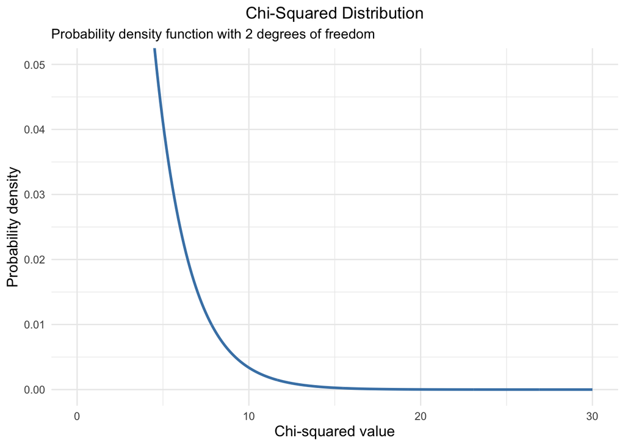

```r
# Load ggplot2
library(ggplot2)

# Define the degrees of freedom
df <- 2

# Create a sequence of x values
x <- seq(0, 30, length.out = 1000)

# Compute the chi-squared density
y <- dchisq(x, df = df)

# Create a data frame
chi_squared_data <- data.frame(x = x, y = y)

# Generate the plot
ggplot(chi_squared_data, aes(x = x, y = y)) +
  geom_line(color = "steelblue", size = 1) + # Line for the density curve
  labs(
    title = "Chi-Squared Distribution",
    subtitle = "Probability density function with 2 degrees of freedom",
    x = "Chi-squared value",
    y = "Probability density"
  ) +
  theme_minimal() +
  coord_cartesian(ylim = c(0, 0.05), xlim = c(0, 30)) +
  theme(
    plot.title = element_text(hjust = 0.5),
    axis.title = element_text(size = 12)
  )
```

**$t$ distribution**

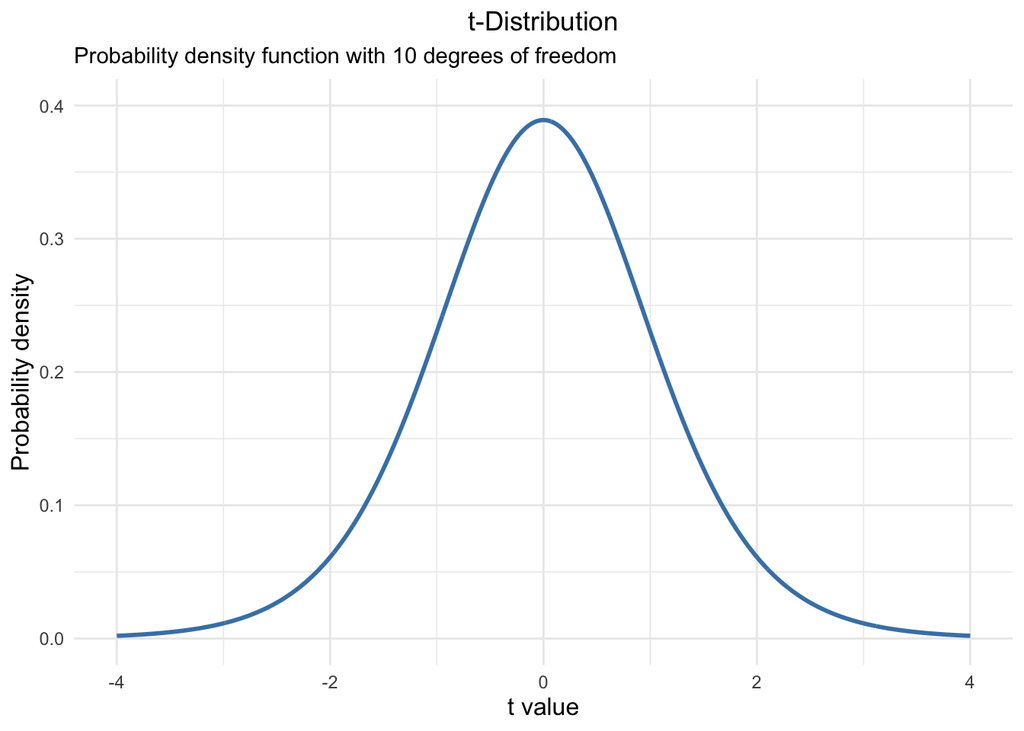

```r
# Define the degrees of freedom
df_t <- 10

# Create a sequence of x values
x_t <- seq(-4, 4, length.out = 1000)

# Compute the t-distribution density
y_t <- dt(x_t, df = df_t)

# Create a data frame
t_distribution_data <- data.frame(x = x_t, y = y_t)

# Generate the plot
ggplot(t_distribution_data, aes(x = x, y = y)) +
  geom_line(color = "steelblue", size = 1) + # Line for the density curve
  labs(
    title = "t-Distribution",
    subtitle = "Probability density function with 10 degrees of freedom",
    x = "t value",
    y = "Probability density"
  ) +
  theme_minimal() +
  coord_cartesian(ylim = c(0, 0.4), xlim = c(-4, 4)) +
  theme(
    plot.title = element_text(hjust = 0.5),
    axis.title = element_text(size = 12)
  )
```

**$F$ distribution**

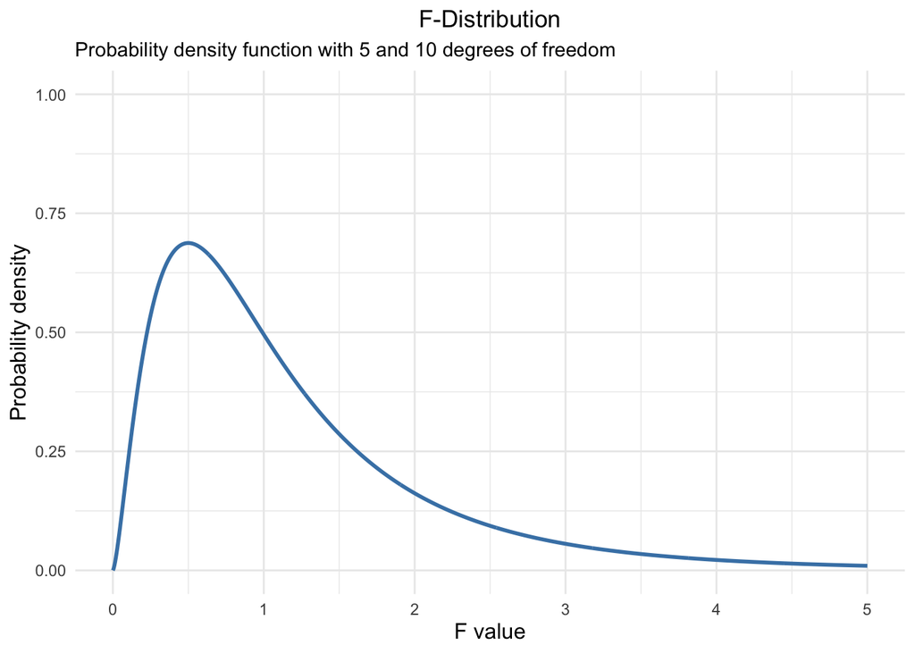

```r
# Define the degrees of freedom
df1 <- 5
df2 <- 10

# Create a sequence of x values
x_f <- seq(0, 5, length.out = 1000)

# Compute the F-distribution density
y_f <- df(x_f, df1 = df1, df2 = df2)

# Create a data frame
f_distribution_data <- data.frame(x = x_f, y = y_f)

# Generate the plot
ggplot(f_distribution_data, aes(x = x, y = y)) +
  geom_line(color = "steelblue", size = 1) + # Line for the density curve
  labs(
    title = "F-Distribution",
    subtitle = "Probability density function with 5 and 10 degrees of freedom",
    x = "F value",
    y = "Probability density"
  ) +
  theme_minimal() +
  coord_cartesian(ylim = c(0, 1), xlim = c(0, 5)) +
  theme(
    plot.title = element_text(hjust = 0.5),
    axis.title = element_text(size = 12)
  )
```

Because continuous functions have an infinite number of $x$-values, the probability of any single value must be 0.[^1] Therefore, if we are interested in obtaining actual probabilities from the PDF, we can only do so for intervals of values. The probability that a value $X$ falls into the interval $a < X < b$ is in fact equivalent to the area under the curve between $a$ and $b$ (cf. Equation 18.2).

<sup>1</sup> The proof for the underlying theorem is given in Heumann et al. (2022: 544).

$$P(a < X < b) = \int_a^b f(x)dx.
\tag{18.2}$$

Recall the PDF $f(x)$ of the $\chi^2$-distribution with 2 degrees of freedom. The $p$-value corresponds to the green area under the curve ranging from $x = 6.5$ up to $\infty$, which can be restated formally in Equation 18.3. This brings us back to the definition of the $p$-value: It is the probability that the $\chi^2$ score is equal to 6.5 or **higher**, i.e., $P(\chi^2 \geq 6.5)$.

$$P(6.5 < X < \infty) = \int_{6.5}^\infty f(x)dx.
\tag{18.3}$$

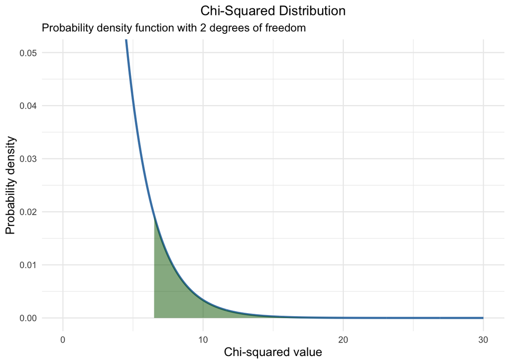

## 18.4 Practical considerations

**Common pitfalls**

- Statistical significance is **NOT** an indication of a causal relationship between the variables of interest (**correlation** $\neq$ **causation**).
- $p$-values do **NOT** signify the strength of an effect ($\neq$ effect size). It only helps identify whether there is an effect to begin with.
- $p$-values are **NOT** the probability of the null hypothesis being true.
- Statistical significance is only a starting point for further scientific inquiry, and by no means the end of it.

Agresti, Alan, and Maria Kateri. 2022. *Foundations of Statistics for Data Scientists: With r and Python*. Boca Raton: CRC Press.

Baguley, Thomas. 2012. *Serious Stats: A Guide to Advanced Statistics for the Behavioral Sciences*. Houndmills, Basingstoke: Palgrave Macmillan.

Dienes, Zoltán. 2008. *Understanding Psychology as a Science: An Introduction to Scientific and Statistical Inference*. Houndmills: Palgrave Macmillan.

Gries, Stefan Thomas. 2021. *Statistics for Linguistics with r: A Practical Introduction*. 3rd rev. ed. Berlin; Boston: De Gruyter Mouton.

Heumann, Christian, Michael Schomaker, and Shalabh. 2022. *Introduction to Statistics and Data Analysis: With Exercises, Solutions and Applications in r*. 2nd ed. Cham: Springer. https://doi.org/10.1007/978-3-031-11833-3.

James, Gareth, Daniela Witten, Trevor Hastie, and Robert Tibshirani. 2021. *An Introduction to Statistical Learning: With Applications in r*. New York: Springer. https://doi.org/10.1007/978-1-0716-1418-1.